# Clean Code

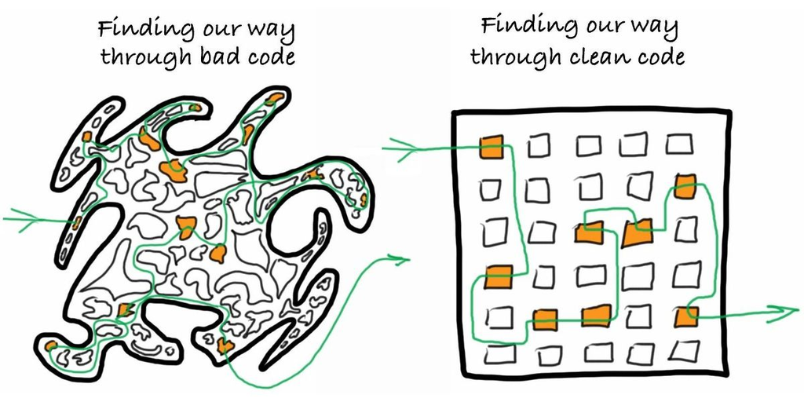

Кирилл Корняков, Андрей Морозов  
Сентябрь 2015

# Содержание

- Зачем?
- Ключевые понятия
- Чистый код
  - Именование
  - Функции/методы
  - Комментарии
  - Форматирование
- Заключение

# Зачем?

> Наши клиенты не смотрят на исходный код.  
> Почему мы должны держать его в чистоте?

Генеральный директор компании по разработке ПО,  
Нижний Новгород, Август 2010

# Преимущества чистого кода

- Программист в основном не пишет, а читает код
- Быстрое понимание кода => быстрое решение задач
  - Добавление новых возможностей
  - Поиск и устранение проблем

# Откуда берется плохой код?

- Нехватка времени
- Отсутствие стандартов кодирования
- Различная квалификация сотрудников
- Низкая культура (уход от ответственности)
- Унаследованный / сторонний код

Кто же виноват?

- Руководство (заказчик, менеджер)
- Коллеги
- На самом деле: **Вы**!

# Как результат...

[figure not shown]

# Содержание

- Зачем?
- **Ключевые понятия**
- Чистый код
  - Именование
  - Функции/методы
  - Комментарии
  - Форматирование
- Заключение

# Что такое качество кода?

[figure not shown]

# Признаки качества кода

## Хорошо

## Плохо

- Простой, логичный, понятный
- Чистый, структурированный
- Краткий, лаконичный
- Единообразный (стилистически единый)
- Непонятный, заумный, сложный
- Запутанный, шумный, визуально нагруженный
- Длинный, повторяющийся
- Беспорядочный, пестрый

# Ключевые понятия

- Дублирование (Duplication)
- Шум (Noise)
- Принцип единой ответственности (Single Responsibility Principle - SRP)
- Ортогональность (Orthogonality)
- Уровни абстракции (Levels of abstraction)
- Единообразие (Uniformity)

# API — самое важное

- Нужно проектировать в первую очередь
- Уделять особое внимание при рецензии кода
- Интерфейс должен быть понятным

```java
Matrix createMatrix(int a1, int a2);
Matrix createMatrix(int width, int height);
List<PECustomerDetailsData> retrieveValidateAndConvertCustomerSpecificDataIntoPresentationEntities();
```

- Избегайте тавтологии

```java
customer.customerName = "Bill";
```

- Сортируйте члены по важности для пользователя

```java
  public void do(); // up

  private int i1;   // down
```